# PAC_1_inferencia_estadística

Raul Perez Prats

2023-11-18

## Ejercicio 1

### A)

#### a)

0.2

#### b)

0.2+0.35+0.15+0.1 = 0.8

#### c)

0.15+0.2 = 0.35

#### d)

0.35/(0.2+0.35+0.15+0.1) = 0.4375

### B)

#### a)

En una distribución continua no se puede determinar la probabilidad de un único número.

#### b)

La probabilidad de que y sea menor que 250 se enuentra en el límite de y tendiendo a 250 por la izquierda, que se aproxima a 0.89 periódico.

#### c)

0.9-0.4 = 0.5

#### d)

0.5/0.9 = 0.55556

## Ejercicio 2

#### a) ¿Cuál es la probabilidad de que un hipertenso esté tratado adecuadamente ( toma tratamiento correcto y cumple las pautas)?

```r
prob_tratado <- 0.5
prob_tratado_adecuadamente <- 0.6
prob_cumple_pautas <- 0.8
respuesta <- prob_tratado*prob_tratado_adecuadamente*prob_cumple_pautas
cat("La probabilidad de que un hipertenso esté tratado adecuadamente es de ", respuesta)
```

```
## La probabilidad de que un hipertenso esté tratado adecuadamente es de  0.24
```

#### b) ¿Cuál es la probabilidad de que de 10 hipertensos al menos el 50% este tratado adecuadamente?

Para resolver esta cuestión aplicaremos usaremos una distribución binomial

```r
x <- 5 # numero de sucesos exitosos
size <- 10 # numero de ensayos
prob <- 0.5 # probabilidad de suceso exitoso

resultado <- dbinom(x,size,prob,log = FALSE)

cat("La probabilidad de que de 10 hipertensos al menos la mitad esté tratado adecuadamente es ", resultado )
```

```
## La probabilidad de que de 10 hipertensos al menos la mitad esté tratado adecuadamente es  0.2460938
```

#### c) ¿Cuál es la probabilidad de que más de 7 de 10 hipertensos conozcan que lo son?

Para resolver esta cuestión volveremos a usar una distribución binomial

La probabilidad de que un hipertenso sea consciente de su patología es del 50%

```r
size <- 10 # numero de ensayos
prob <- 0.5 # probabilidad de suceso exitoso

resultado <- sum(dbinom(8:10, size, prob)) # tambe 1-pbinom(7, size, prob)

cat("La probabilidad de que más de 7 de cada 10 hipertensos sepan que padecen esta patología es de ", resultado )
```

```
## La probabilidad de que más de 7 de cada 10 hipertensos sepan que padecen esta patología es de  0.0546875
```

#### d) Si la mortalidad en los hipertensos no tratados adecuadamente es del 10% y sabiendo que la mortalidad se reduce un 20% si el tratamiento es correcto. ¿Cuál es la probabilidad de muerte (pm) de todos los hipertensos en la población?

```r
prob_no_tratado <- 0.5
prob_tratado <- 0.5
prob_trat_correcto <- 0.6
prob_trat_incorrecto <- 0.4
prob_cumplir_trat <- 0.8
prob_no_cumplir_trat <- 0.2
prob_morir_trat_correcto <- 0.08 # 80% de 0.1
prob_morir_trat_incorrecto <- 0.1

prob_muerte_hipertensos <- prob_no_tratado*prob_morir_trat_incorrecto  +
                           prob_tratado*prob_trat_correcto*prob_no_cumplir_trat*prob_morir_trat_incorrecto+
                           prob_tratado*prob_trat_correcto*prob_cumplir_trat*prob_morir_trat_correcto+
                           prob_tratado*prob_trat_incorrecto*prob_morir_trat_incorrecto

cat("La probabilidad de muerte de todos los hipertensos en la población es de ", prob_muerte_hipertensos)
```

```
## La probabilidad de muerte de todos los hipertensos en la población es de  0.0952
```

#### e) Genera una muestra aleatoria de 10 hipertensos asumiendo que en la población la mortalidad es la calculada en el apartado d).Estima la probabilidad de muerte y su intervalo de confianza al 95% a partir de la muestra extraída. Interpreta los resultados.

Generamos una muestra aleatoria con 10 hipertensos con la probabilidad de muerte de 0.0952, a partir de esta muestra volvemos a caluclar la probabilidad de muerte, a partir de esta muestra y su probabilidad de muerte calculamos los intervalos de confianza y graficamos la distribución binomial ajustada por MLE.

```r
set.seed(123)

muestra_aleatoria <- rbinom(10, size = 1, prob = 0.0952)

count_ones <- sum(muestra_aleatoria == 1)
count_total <- sum(muestra_aleatoria == 0) + count_ones
pm <- count_ones/count_total

#intervalos de confianza -> no ho podem fer aixi perque ens demana de la mostra extreta a partir d'aquesta distribució
#intervalo_confianza <- qbinom(c(0.025,0.975),10,0.0952)

cat("La muestra aleatoria es  ", muestra_aleatoria,"\n")
```

```
## La muestra aleatoria es   0 0 0 0 1 0 0 0 0 0
```

```r
cat("La probabilidad de muerte en esta muestra es", pm)
```

```
## La probabilidad de muerte en esta muestra es 0.1
```

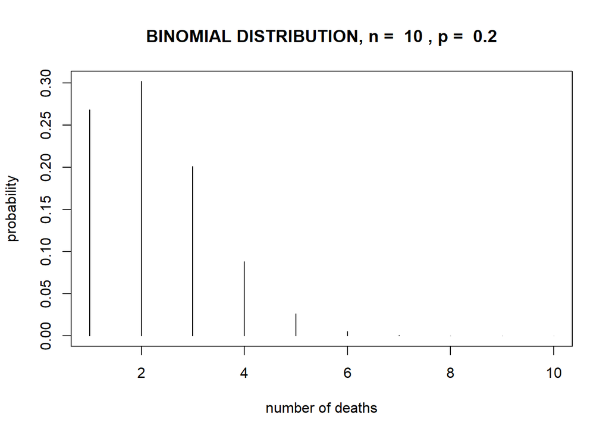

```
##
## [1] "IC(95%) =  0 - 5"
```

```r
#Representación gráfica de la distribución

RandomBinomMLE = function(n,prob){
  x = rbinom(n,1,prob)
  p = length(x[x==1])/n
  q = qbinom(c(0.025,0.975),n,p)
  plot(1:n,dbinom(1:n,n,p),type='h',xlab="number of deaths",ylab="probability",
       main= paste("BINOMIAL DISTRIBUTION, n = ",n,", p = ",p))
  cat("\n")
  print(paste("IC(95%) = ",q[1],"-",q[2])) # probabilitat estimada a partir del mostreig
}

RandomBinomMLE(10,0.0952)
```

Vemos que todo y haver creado una muestra con una pm = 0.0952 al ser una muestra con pocos individuos la pm varía, y toma un valor de 0.2. La distribución tiene una clara forma de binomial.

#### f) Repite el ejercicio anterior, pero con una muestra de 500 hipertensos . Interpreta los resultados.

```r
set.seed(123)

muestra_aleatoria <- rbinom(500, size = 1, prob = 0.0952)

count_ones <- sum(muestra_aleatoria == 1)
count_total <- sum(muestra_aleatoria == 0) + count_ones
pm <- count_ones/count_total

cat("La muestra aleatoria es  ", muestra_aleatoria,"\n")
```

```
## La muestra aleatoria es   0 0 0 0 1 0 0 0 0 0 1 0 0 0 0 0 0 0 0 1 0 0 0 1 0 0 0 0 0 0 1 0 0 0 0 0 0 0 0 0 0 0 0 0 0 0 0 0 0 0 0 0 0 0 0 0 0 0 0 0 0 0 0 0 0 0 0 0 0 0 0 0 0 0 0 0 0 0 0 0 0 0 0 0 0 0 1 0 0 0 0 0 0 0 0 0 0 0 0 0 0 0 0 1 0 0 1 0 0 0 1 0 0 1 0 0 0 1 0 0 0 0 0 0 0 1 0 0 0 0 0 0 0 0 0 0…
```

```r
cat(" La probabilidad de muerte es",pm)
```

```
##  La probabilidad de muerte es 0.092
```

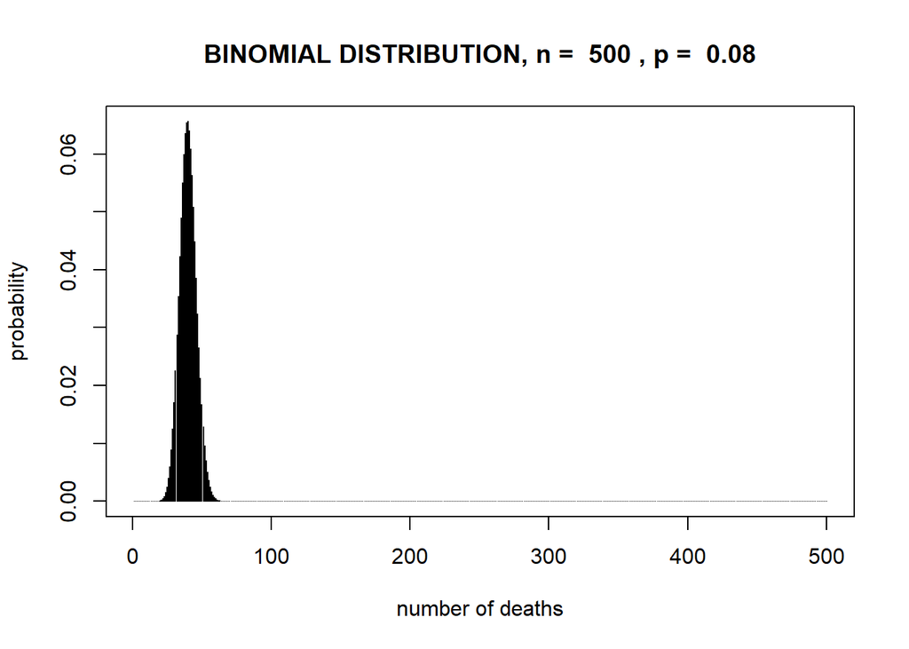

```
##
## [1] "IC(95%) =  29 - 52"
```

```r
#Representación gráfica de la distribución


RandomBinomMLE(500,0.0952)
```

#### g) Si en lugar de 1 muestra se extrajeran 1000 muestras y se estimara la probabilidad de muerte y sus intervalos de confianza de cada muestra . En cuantos intervalos de los calculados se espera que esté incluida pm (verdadera probabilidad de muerte en la población) (Nota se trata de una pregunta teórica)

Si se extrajeran 1000 muestras de 500 individuos y se estimara la probabilidad de muerte y sus intervalos de confianza, esperariamos encontrar incluida la pm en 950 de éstos 1000 intervalos, ya que el intervalo de confianza del 95% indica que generando un número infinito de intervalos de confianza en infinitas muestras, el 95% de éstos intervalos contendrán el valor buscado (pm) en su rango.

## Ejercicio 3

#### a) ¿Cuál es el porcentaje de hipertensos en esta población?.

```r
probability_superior_140 <- 1- pnorm(140, mean = 124, sd = 10)

cat("La probabilidad de tener una tension arterial sistolica superior a 140mmHg es de", probability_superior_140)
```

```
## La probabilidad de tener una tension arterial sistolica superior a 140mmHg es de 0.05479929
```

### b) ¿Cuál es el valor de corte de tas que dejaría sólo al 5% de hipertensos en esta población?

```r
valor_5_por_cien <- qnorm(0.995, mean = 124, sd = 10)

cat("El valor de corte de TAS qe dejaría sólo al 5% de hipertensos en esta población es", valor_5_por_cien)
```

```
## El valor de corte de TAS qe dejaría sólo al 5% de hipertensos en esta población es 149.7583
```

#### c) Extrae una muestra de 50 personas de la población y estima la media de la tas y su intervalo de confianza al 99%

```r
set.seed(123)
muestra_50 <- rnorm(50, mean = 125, sd = 10 )

media_muestral <- mean(muestra_50)
standard_deviation <- sd(muestra_50)

#Estimación del intervalo de confianza

intervalo_confi <- qnorm(c(0.0005,0.9995), mean = media_muestral, sd = standard_deviation)

cat("La media de la TAS es", media_muestral,"mmHg","con un intervalo de confianza 99% de", "(",intervalo_confi[1],",",intervalo_confi[2],")")
```

```
## La media de la TAS es 125.344 mmHg con un intervalo de confianza 99% de ( 94.87804 , 155.81 )
```

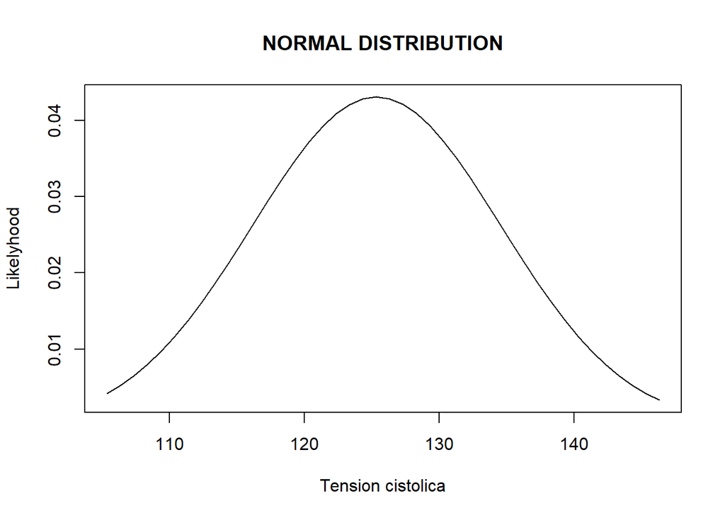

```r
# Plot the normal distribution with confidence intervals

minim_tensio <- min(muestra_50)
maxim_tensio <- max(muestra_50)

x_values <- minim_tensio:maxim_tensio

# Calculate the probability density function (PDF) for each value in the sample
y_values <- dnorm(x_values, mean = media_muestral, sd = standard_deviation)

# Plot the normal distribution
plot(x_values, y_values, type = 'l', xlab = "Tension cistolica", ylab = "Likelyhood",
     main = paste("NORMAL DISTRIBUTION"))
```

#### d) ¿Qué porcentaje de sujetos de la muestra se clasificarían como hipertensos? Justifica porqué este porcentaje es diferente del apartado a

```r
count_hipertensos <- sum(muestra_50 > 140)
porcentaje_hipertensos <- (count_hipertensos/length(muestra_50))*100

cat("Un",porcentaje_hipertensos ,"% personas con valors de hipertension superiores a 140 en la muestra")
```

```
## Un 8 % personas con valors de hipertension superiores a 140 en la muestra
```

#### e) ¿Qué tamaño muestral sería el necesario para obtener un intervalo de confianza al 99% con un error máximo deseable de 2mmHg?

Sabemos que para calcular el error de un intérvalo de confianza: E = z * sd/√n

```r
E <- 2
z <- 2.58
sd <- 10

#aislamos n

n<- (z*sd/E)^2

cat("El tamaño muestral necesario para un intervalo de confianza del 99% con un error de 2mmHg es:",ceiling(n))
```

```
## El tamaño muestral necesario para un intervalo de confianza del 99% con un error de 2mmHg es: 167
```